# Week-Two Homework

Bethany Poulin

9/5/2019

## R Markdown

The plastics data set consists of the monthly sales (in thousands) of product A for a plastics manufacturer for five years.

1. Plot the time series of sales of product A. Can you identify seasonal fluctuations and/or a trend-cycle?

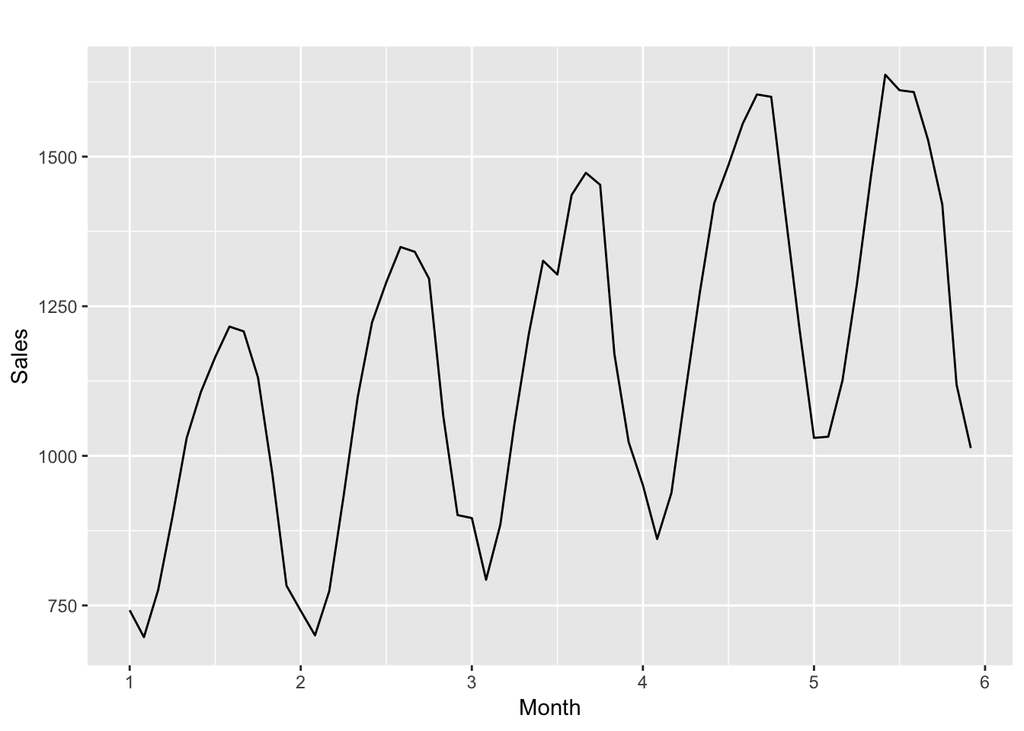

```r
plastics%>%
  autoplot() +
  xlab('Month') +
  ylab('Sales')
```

It is clear that there is some periodicity in the plot as the peaks and valleys are progressing in a consistently repeating pattern, while at the same time there is a rising overall value, implying that there is also a trend component to this data set.

2. Use a classical multiplicative decomposition to calculate the trend-cycle and seasonal indices.

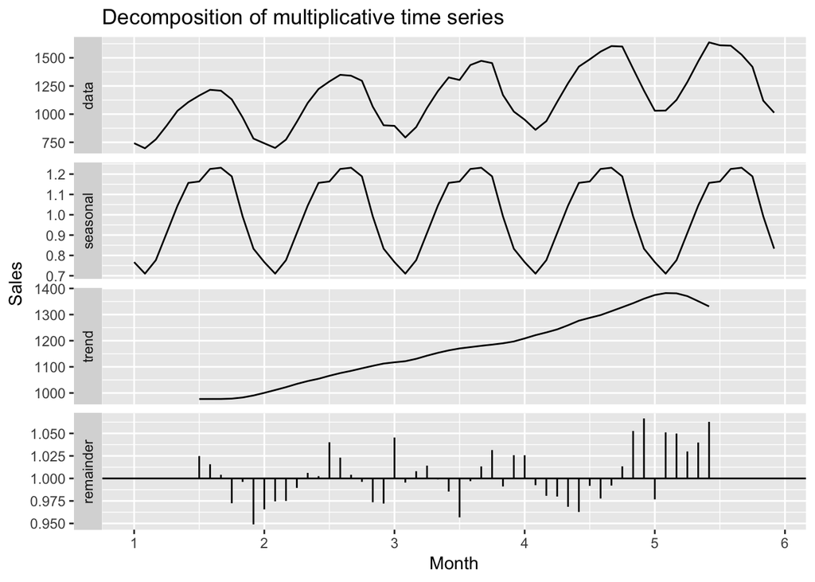

```r
  plastics%>%
  decompose( type="multiplicative")%>%
  autoplot() +
  xlab('Month') +
  ylab('Sales')
```

3. Do the results support the graphical interpretation from part a?  
   Yes, when decomposed, the trend becomes very clearly upward, while a rather unvarying seasonal component emmerges. The one very interesting component is the random, component, it does seem to imply an unexpained mechanism (with some variability over time).
4. Compute and plot the seasonally adjusted data.

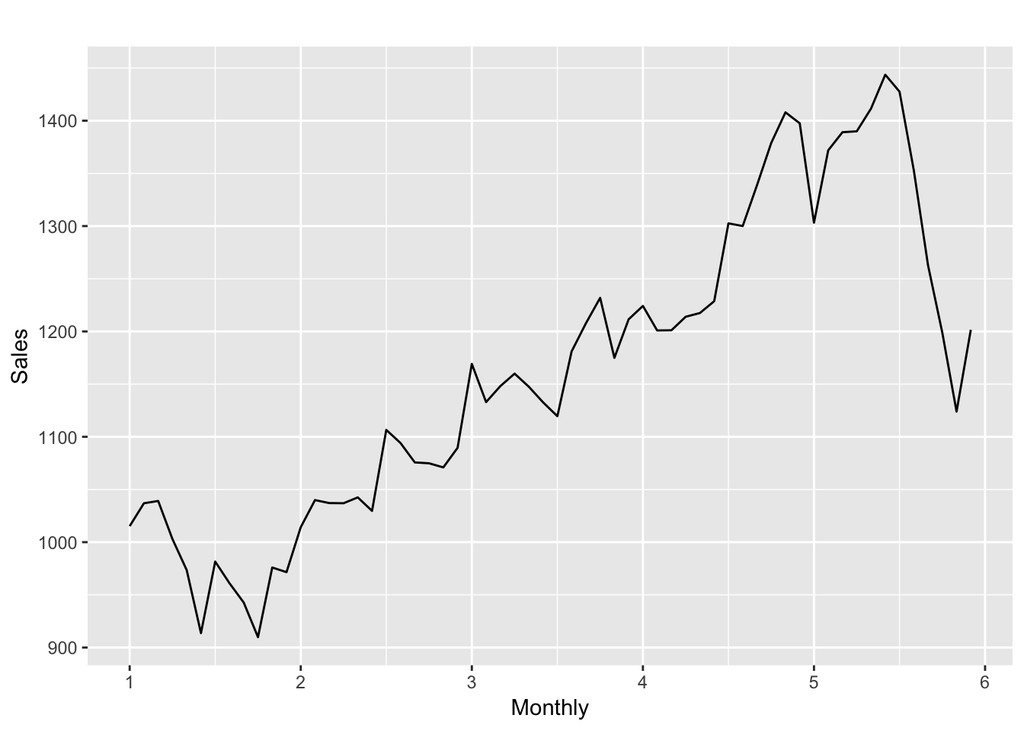

```r
fit <- decompose(plastics)
  seasadj(fit)%>%
  autoplot() +
  ylab('Sales') +
  xlab('Monthly')
```

5. Change one observation to be an outlier (e.g., add 500 to one observation), and recompute the seasonally adjusted data. What is the effect of the outlier?

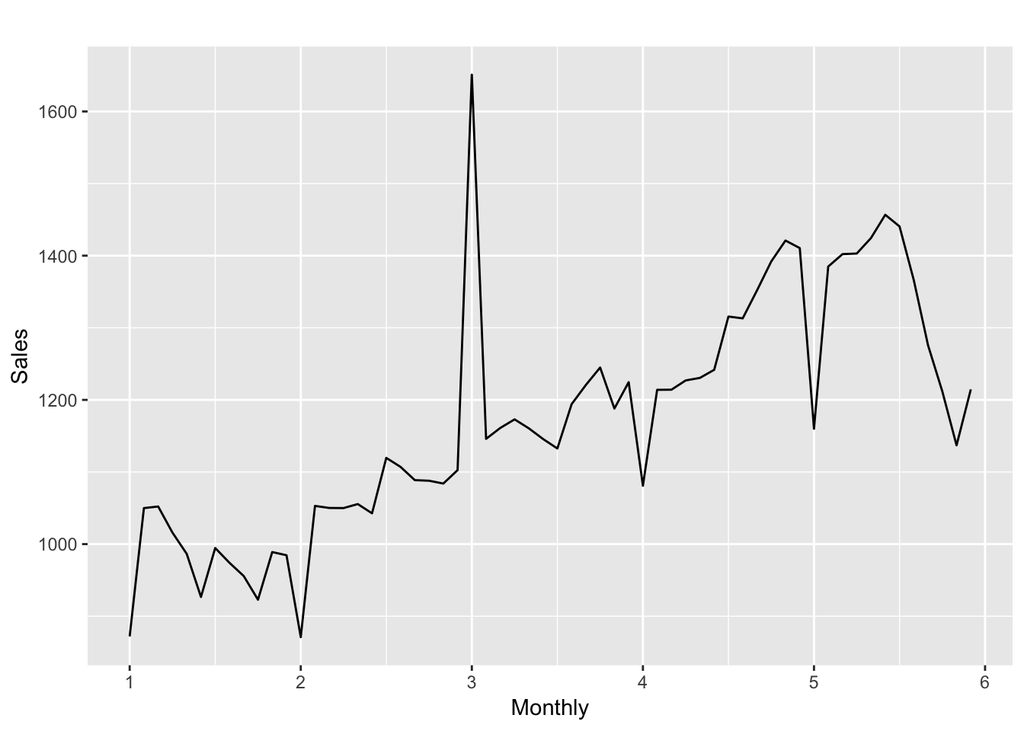

```r
plastics_2 <-plastics
plastics_2[25]<- plastics[25]+625
fit <- decompose(plastics_2)
seasadj(fit)%>%
  autoplot()+
  ylab('Sales') +
  xlab('Monthly')
```

6. Does it make any difference if the outlier is near the end rather than in the middle of the time series?

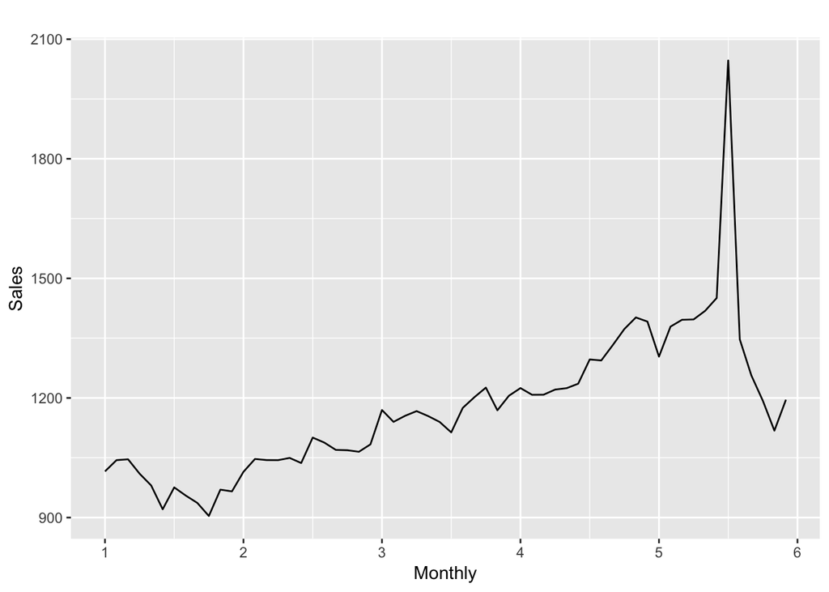

```r
plastics_3 <-plastics
plastics_3[55]<- plastics[55]+625
fit <- decompose(plastics_3)
seasadj(fit)%>%
  autoplot()+
  ylab('Sales') +
  xlab('Monthly')
```